# Visualize This: Patterns over time

by* [*Michael L. Bernauer*](http://mlbernauer.bitbucket.org/)

03/08/2015

## Creating a Bar Graph

In this example we will create a bar graph to show results from the past three decades of Nathan’s Hot Dog Eating Contest.

## Read in the data

First we must read in the data. Lucky for us Nathan Yau has provided us with a nicely formatted database.

```r
hotdogs <- read.csv("http://datasets.flowingdata.com/hot-dog-contest-winners.csv", sep=",", header=TRUE)
head(hotdogs)
```

```
##   Year                       Winner Dogs.eaten       Country New.record
## 1 1980 Paul Siederman & Joe Baldini       9.10 United States          0
## 2 1981              Thomas DeBerry       11.00 United States          0
## 3 1982               Steven Abrams       11.00 United States          0
## 4 1983                 Luis Llamas       19.50        Mexico          0
## 5 1984               Birgit Felden        9.50       Germany          0
## 6 1985             Oscar Rodriguez       11.75 United States          0
```

## Designing the plot using R-base graphics

We are interested in showing the number of HDBs eaten over time. To acheive this, we will plot the number of HDBs eaten by the winner for each year.

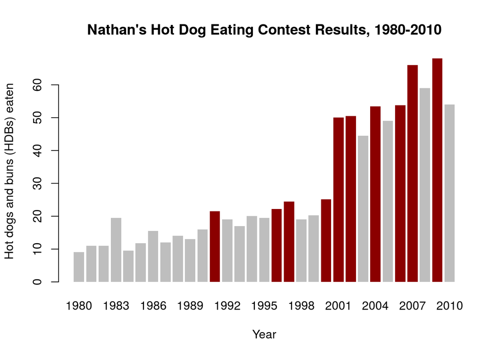

```r
colors <- ifelse(hotdogs$New.record == 1, "darkred", "grey")
barplot(hotdogs$Dogs.eaten, names.arg = hotdogs$Year, col=colors, border=NA,
        main = "Nathan's Hot Dog Eating Contest Results, 1980-2010",
        xlab="Year", ylab="Hot dogs and buns (HDBs) eaten")
```

## Designing the plot using ggplot2 graphics

Now let’s try to create the same figure using `ggplot2`.

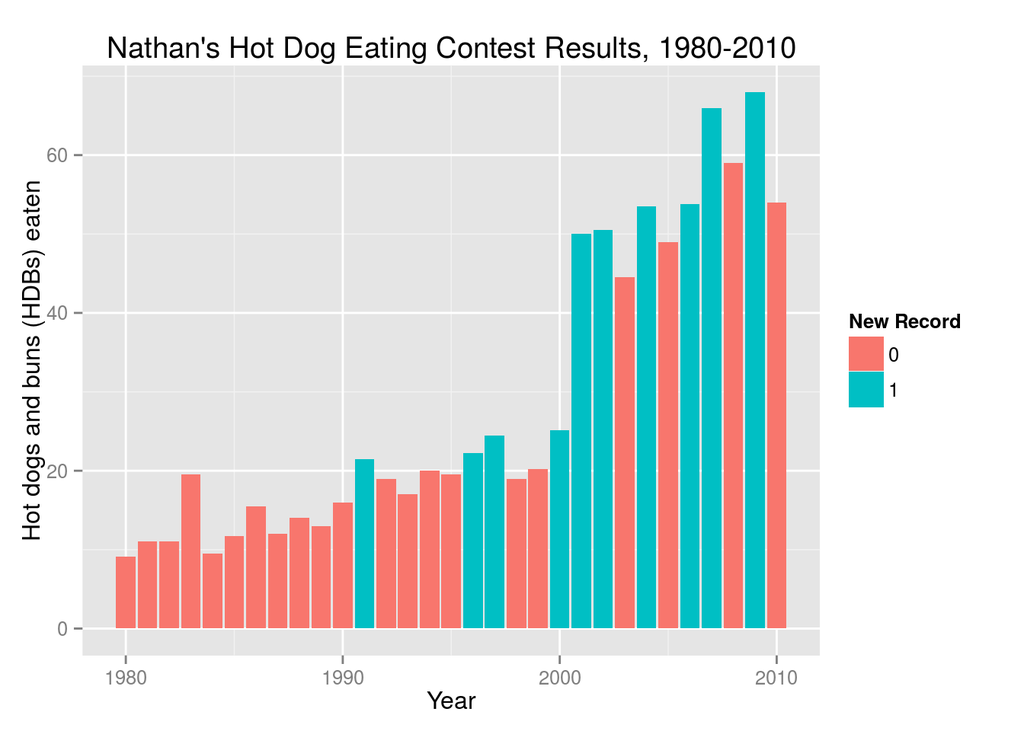

```r
library(ggplot2)
ggplot(hotdogs) + geom_bar(aes(x=Year, y=Dogs.eaten, fill=factor(New.record)), stat="identity") +
  labs(title="Nathan's Hot Dog Eating Contest Results, 1980-2010", fill="New Record") + xlab("Year") +
  ylab("Hot dogs and buns (HDBs) eaten")
```

## Stacked bar plot using R-base graphics

Instead of viewing the number of HDBs eaten by the top contestant for each year we can view the top three.

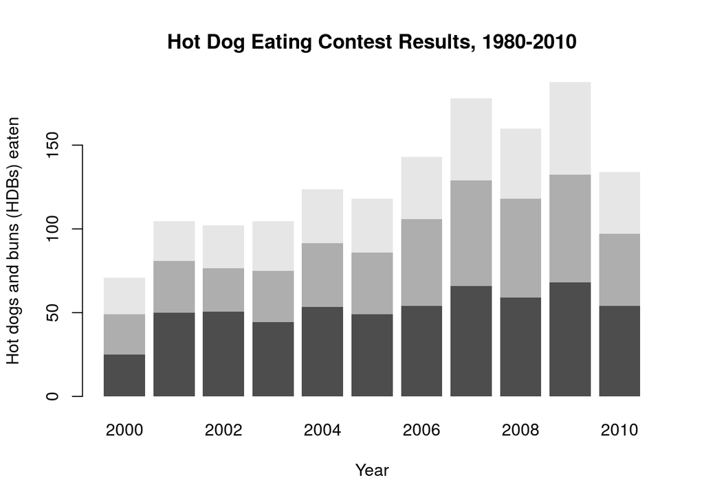

```r
# Read in the data, each row is a different contestant
hotdog_places <- read.csv("http://datasets.flowingdata.com/hot-dog-places.csv", sep=",", header=TRUE)
# Convert to matrix
hotdog_places <- as.matrix(hotdog_places)
# Rename the columns to correspond to the years 2000-2010
colnames(hotdog_places) <- lapply(2000:2010, as.character)
barplot(hotdog_places, border=NA, main="Hot Dog Eating Contest Results, 1980-2010", xlab="Year",
        ylab="Hot dogs and buns (HDBs) eaten")
```